# NCAA Men’s College Basketball Analysis

Jake Whalen

# 1 Purpose

The purpose of this project is to explore the Mens NCAA March Madness (MM) data for insight into what gives teams a winning advantage. The findings here will help to provide a starting point for building a model that predicts winners.

# 2 Data

The data for this project was downloaded from the [Google Cloud & NCAA March Madness Analytics](https://www.kaggle.com/c/march-madness-analytics-2020/data) Kaggle competition. The project focuses on the data from the NCAA Men’s league. The list of data files below were included in this analysis. The data goes back to 1985. The reason for cutting off at 1985 is because that was the first year the tournament expanded to 64 teams, the current format. Although today there are 68 teams due to the addition of 4 play-in games that take place in the days leading up to the start of the tournament.

```r
folder <- 'C:/Users/Jake/Documents/Projects/UVA-CBB/data/MDataFiles_Stage1'
files <- list.files(folder)
dfs <- list()

for (f in files){
    df.name <- str_replace(f, '.csv', '')
    dfs[[df.name]] <- vroom(file.path(folder, f))
}
files
```

```
##  [1] "Cities.csv"                          "Conferences.csv"
##  [3] "MConferenceTourneyGames.csv"         "MGameCities.csv"
##  [5] "MMasseyOrdinals.csv"                 "MNCAATourneyCompactResults.csv"
##  [7] "MNCAATourneyDetailedResults.csv"     "MNCAATourneySeedRoundSlots.csv"
##  [9] "MNCAATourneySeeds.csv"               "MNCAATourneySlots.csv"
## [11] "MPlayers.csv"                        "MRegularSeasonCompactResults.csv"
## [13] "MRegularSeasonDetailedResults.csv"   "MSeasons.csv"
## [15] "MSecondaryTourneyCompactResults.csv" "MSecondaryTourneyTeams.csv"
## [17] "MTeamCoaches.csv"                    "MTeamConferences.csv"
## [19] "MTeams.csv"                          "MTeamSpellings.csv"
```

In addition to the files above there are play-by-play records since 2015. These files contain individual records for every event that occured in every game. There is potential for the data to not be 100% accurate as described on the Kaggle site. For this reason and because it is only available for the last 5 seasons I have decided to exclude the play-by-play from this analysis.

```r
# folder <- 'C:/Users/Jake/Documents/Projects/UVA-CBB/data'
# files <- list.files(folder, pattern = "MEvents")
# pbp <- list()
#
# for (f in files){
#     df.name <- str_replace(f, '.csv', '')
#     pbp[[df.name]] <- vroom(file.path(folder, f))
# }
# files
```

# 3 Exploratory Data Analysis (EDA)

The following sections show the results of the analysis done to identify the patterns and trends in winners. This is not an exhaustive analysis of all possible patterns and trends. Some of the findings support well known patterns (i.e. higher seeds beat lower seeds more frequently) while others attempt to uncover lesser known patterns.

## 3.1 The Growth of a League

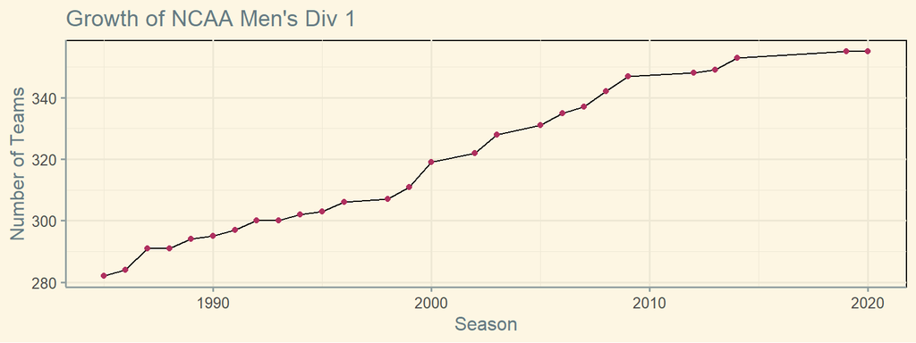

```r
left_join(dfs$MTeams %>%
              group_by(Season = FirstD1Season) %>% summarise(First = n()),
          dfs$MTeams %>%
              group_by(Season = LastD1Season) %>% summarise(Last = n()),
          by = 'Season') %>%
    mutate(Last = ifelse(is.na(Last), 0, Last),
           fCS = cumsum(First),
           lCS = cumsum((Last)),
           current = fCS - lag(lCS),
           current = ifelse(is.na(current), First, current)) %>%
    ggplot(aes(x=Season, y=current)) +
    geom_line() +
    geom_point(color = 'maroon') +
    labs(title = "Growth of NCAA Men's Div 1",
         y = 'Number of Teams', x = 'Season') +
    my_theme
```

## 3.2 Regular Season

## 3.3 March Madness

### 3.3.1 Tournament Seeding

Selection Sunday is the Sunday on the final weekend of the regular season when conference tournaments wrap up. The name comes from the fact that on that day the 64 (68 including play-ins) teams are selected on live TV to compete in MM. While some teams are waiting to find out if they will be invited, a majority already know with almost near certainty that they will be given an invite. Those teams who know they are in are mostly interested to see what their seed is and who their opponents will be.

Seeding in the tournament is very important. It is widely considered that the higher the seed the better chance you have at making the Final Four and winning the National Championship. The lowest seed to ever win the championship was Villanova at the 8 spot. This isn’t to say seeds below an 8 should be counted out, but history is not on their side.

#### 3.3.1.1 Seed Matchup Performance

The graphic below shows the winnig percentage amongst seed matchups. The seeds denoted on the y-axis are the winners while the seeds across the x-axis are the losers. The diagonal (equal seeded matchups) were removed from this chart since there was no comparison (1 seed has a 100% win rate against 1 seeds with a 100% losing rate at the same time). A blank indicates the two seeds have never matched up before in the tournament. When viewing this chart it is important to remind yourself that not all of these matchups are as common as others. For instance a 1 vs 16 and a 8 vs 9 are guaranteed to be played four times every single tournament because those are first round games.

A few quick takeaways from the graphic below:

- 1 Seeds:
  - Have lost to a 16 only one time in the history of the tournament.
  - As expected, have a greater than 50% winning percentage against all other seeds.
  - Have never faced a 14 or 15 seed due to these lower seeds never advancing far enough (Elite 8).
  - Struggle with the 11 seeds, only posting a 57% winning percentage.
- Being a 2 seed doesn’t look as good as it sounds.
  - 0 wins over 5 and 9 seeds.
  - An abysmal 29% winning percentage over 8 seeds.
- In recent memory the 5 vs 12 is a common upset pick in many brackets however the 12 seed only holds a 36% winning percentage in this matchup.

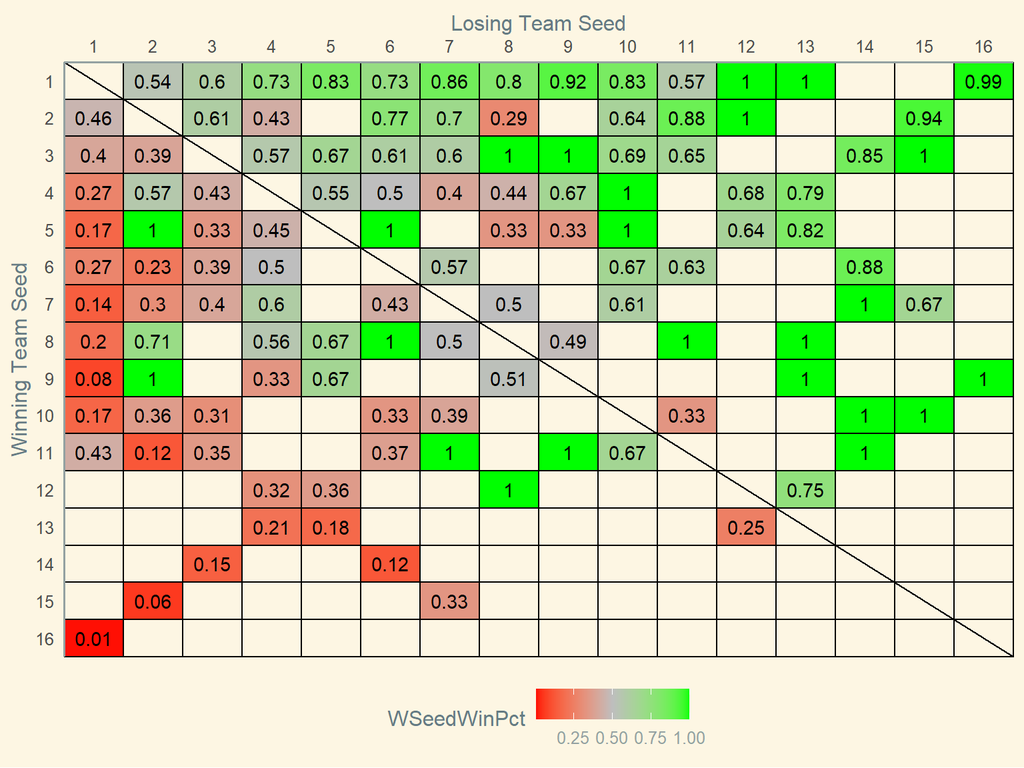

```r
df.seed.results <-
    dfs$MNCAATourneyCompactResults %>%
    select(Season, DayNum, WTeamID, LTeamID) %>%
    left_join(.,
              dfs$MNCAATourneySeeds %>% rename(WTeamID = TeamID, WSeed = Seed),
              by = c('Season', 'WTeamID')) %>%
    left_join(.,
              dfs$MNCAATourneySeeds %>% rename(LTeamID = TeamID, LSeed = Seed),
              by = c('Season', 'LTeamID')) %>%
    mutate(WSeed = str_replace(WSeed, 'a', ''),
           WSeed = str_replace(WSeed, 'b', ''),
           LSeed = str_replace(LSeed, 'a', ''),
           LSeed = str_replace(LSeed, 'b', ''),
           WReg = substr(WSeed, 1, 1),
           LReg = substr(LSeed, 1, 1),
           W_L_Regions = paste(WReg, LReg, sep = "/"),
           WSeed = as.numeric(substr(WSeed, 2, 3)),
           LSeed = as.numeric(substr(LSeed, 2, 3)))

df.wvl.seed <-
    df.seed.results %>%
    group_by(WSeed, LSeed) %>%
    summarise(WSeedWins = n())

df.wvl.seed %>%
    left_join(.,
              df.wvl.seed %>%
                  rename(LSeed = WSeed, WSeed = LSeed,
                         LSeedWins = WSeedWins),
              by = c('WSeed', 'LSeed')) %>%
    filter(WSeed != LSeed) %>%
    mutate(LSeedWins = ifelse(is.na(LSeedWins), 0, LSeedWins),
           WSeedWinPct = WSeedWins / (WSeedWins + LSeedWins)) %>%
    ggplot(aes(x=LSeed, y=WSeed, fill=WSeedWinPct)) +
    geom_tile() +
    geom_text(aes(label = round(WSeedWinPct, 2))) +
    geom_segment(aes(x=0.5, y=0.5, xend=16.5, yend=16.5)) +
    geom_hline(yintercept = 0.5:16.5) +
    geom_vline(xintercept = 0.5:16.5) +
    scale_y_continuous(trans = "reverse", breaks = 1:16, expand = c(0,0)) +
    scale_x_continuous(position = "top", breaks = 1:16, expand = c(0,0)) +
    scale_fill_gradient2(low = 'red', mid='grey',
                         high='green', midpoint = 0.5) +
    my_theme +
    theme(axis.ticks = element_blank(),
          legend.position = 'bottom',
          panel.grid.major = element_blank()) +
    labs(x = 'Losing Team Seed', y = 'Winning Team Seed')
```

#### 3.3.1.2 Average Seed vs MM Winning Percentage

The graph below plots each teams average tournamnet seed (x-axis) against their tournamnet winning percentage all-time (y-axis). The graph illustrates what most would expect, higher seeds (lower on x-axis) win more games in the tournament (higher on the y-axis). You see the blue bloods in the top left corner as expected. Loyola-Chicago seems to be a bit of an outlier. This is primarily due to their Final Four run in 2018 as an 11 seed. Prior to that they had been to the tournament one time as a 4 seed in 1985. On the other end there is a team like TCU who has consistently underperformed there seeding. With three trips to the tournament as a 4, 5, and 6 seed they have posted a sub 30% winning percentage.

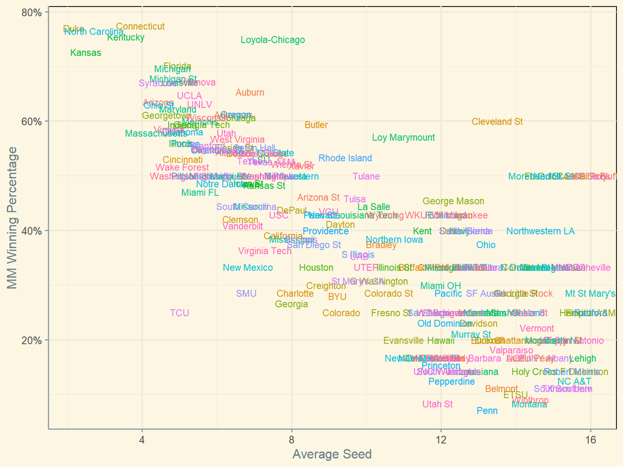

```r
team.seeds <-
    dfs$MNCAATourneySeeds %>%
    mutate(Seed = str_replace(Seed, 'a', ''),
           Seed = str_replace(Seed, 'b', ''),
           Region = substr(Seed, 1, 1),
           Seed = as.numeric(substr(Seed, 2, 3))) %>%
    left_join(.,
              dfs$MTeams %>% select(TeamID, TeamName))

team.seeds.summ <-
    team.seeds %>%
    group_by(TeamName) %>%
    summarise(Appearances = n(), AvgSeed = mean(Seed),
              High = max(Seed), Low = min(Seed)) %>%
    ungroup()

#Avg Seed vs Winning %
#filter(dfs$MNCAATourneySeeds, TeamID == filter(dfs$MTeams, TeamName == 'Cleveland St')$TeamID)
dfs$MNCAATourneyCompactResults %>%
    group_by(TeamID = WTeamID) %>%
    summarise(Wins = n()) %>%
    left_join(.,
              dfs$MNCAATourneyCompactResults %>%
                  group_by(TeamID = LTeamID) %>%
                  summarise(Losses = n()),
              by = 'TeamID') %>%
    left_join(.,
              dfs$MTeams %>% select(TeamID, TeamName),
              by = 'TeamID') %>%
    mutate(WinPct = Wins / (Wins + Losses)) %>%
    select(TeamName, WinPct) %>%
    left_join(., team.seeds.summ, by = 'TeamName') %>%
    ggplot(aes(x=AvgSeed, y=WinPct)) +
    geom_text(aes(label = TeamName, color = TeamName),
              size = 3, show.legend = F) +
    my_theme +
    labs(y = 'MM Winning Percentage', x = 'Average Seed') +
    scale_y_continuous(labels = scales::percent)
```

### 3.3.2 Tournament History of Individual Teams

The graphs below take a look at the frequency with which teams made the tournament over the past 35 seasons (left) and their average seed when making the tournament (right). These graphics confirm what most who follow college basketball already knew, the blue bloods (Duke, UNC, UK, KU) are nicknamed that for a reason. The consistently make the tournament and they are consistently given high seeds.

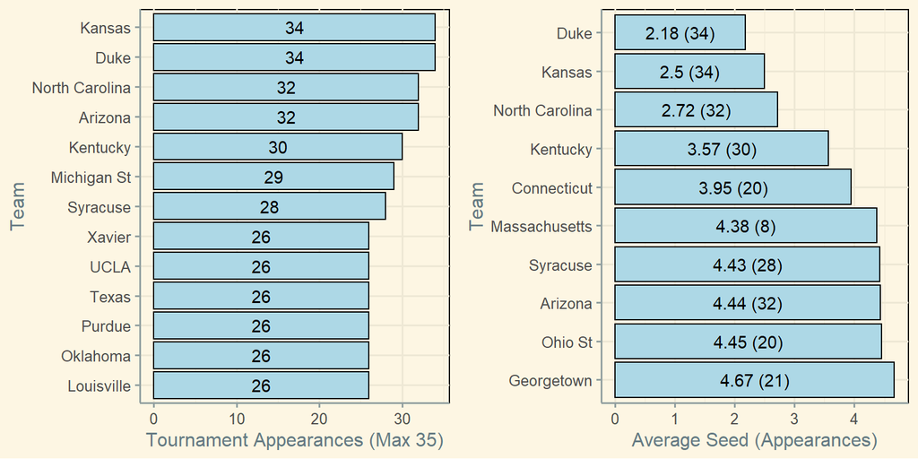

```r
#Teams history of being seeded
p1 <- team.seeds.summ %>%
    ungroup() %>%
    mutate(rank = rank(-Appearances, ties.method = 'min')) %>%
    filter(rank <= 10) %>%
    ggplot(aes(x = Appearances, y=reorder(TeamName, Appearances))) +
    geom_bar(stat = 'identity', fill = 'lightblue', color = 'black') +
    geom_text(aes(x=Appearances/2, label = Appearances)) +
    my_theme +
    labs(y = 'Team', x = 'Tournament Appearances (Max 35)')

#Teams average seed
p2 <- team.seeds.summ %>%
    mutate(rank = rank(AvgSeed, ties.method = 'min')) %>%
    filter(rank <= 10) %>%
    ggplot(aes(x = AvgSeed, y=reorder(TeamName, -AvgSeed))) +
    geom_bar(stat = 'identity', fill = 'lightblue', color = 'black') +
    geom_text(aes(x=AvgSeed/2, label = sprintf("%s (%s)", round(AvgSeed, 2), Appearances))) +
    my_theme +
    labs(y = 'Team', x = 'Average Seed (Appearances)')

grid.arrange(p1, p2, ncol=2)
```

### 3.3.3 Team Conferences

#### 3.3.3.1 Conference Matchup Performance MM

Since 1985 there have been a total of 51 conferences in the college basketball landscape. The chart below shows how each conference has faired in tournament games against other conferences. In order to make the graphic below more legible, only the results for conferences still competing in 2019-20 are displayed. Each row contains the conferences winning percentage against all other conferences. For teams that moved conferences (i.e. Syracuse or Louisville) their results are applied to the conference that they belonged to at the time.

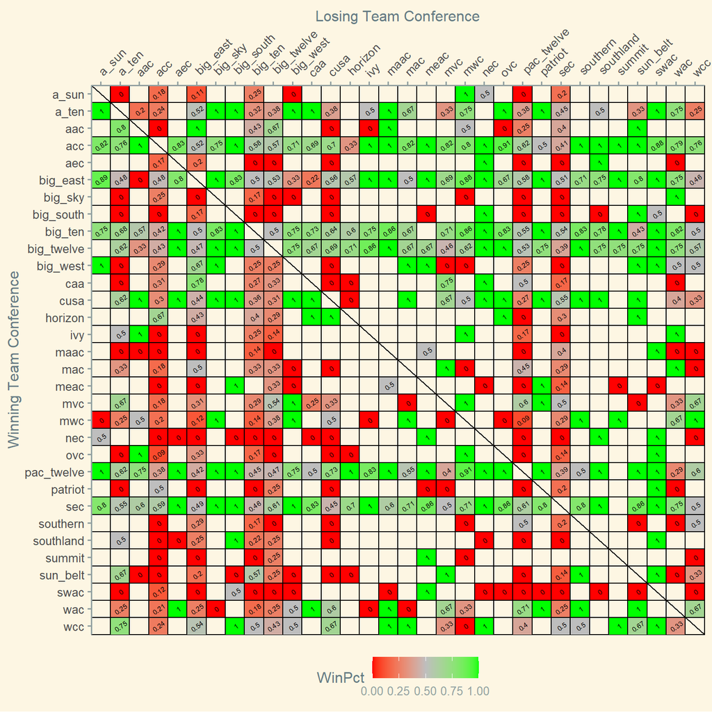

```r
#Conf vs conf
cnf_v_cnf <-
    dfs$MNCAATourneyCompactResults %>%
    select(Season, WTeamID, LTeamID) %>%
    left_join(.,
              dfs$MTeamConferences %>%
                  rename(WTeamID = TeamID, WConf = ConfAbbrev)) %>%
    left_join(.,
              dfs$MTeamConferences %>%
                  rename(LTeamID = TeamID, LConf = ConfAbbrev)) %>%
    group_by(WConf, LConf) %>%
    count()

keep_conf <-
    dfs$MTeamConferences %>%
    filter(Season == 2020) %>%
    group_by(ConfAbbrev) %>%
    count() %>%
    select(Conf = ConfAbbrev) %>%
    .[[1]]

cnf_v_cnf %<>%
    filter(WConf %in% keep_conf, LConf %in% keep_conf)

cnf_v_cnf %>%
    full_join(.,
              cnf_v_cnf %>%
                  rename(WConf = LConf,
                         LConf = WConf,
                         n_L = n)) %>%
    filter(WConf != LConf) %>%
    mutate(n = ifelse(is.na(n), 0, n),
           n_L = ifelse(is.na(n_L), 0, n_L),
           WinPct = n / (n + n_L)) %>%
    ggplot(aes(y=WConf, x=LConf, fill=WinPct)) +
    geom_tile() +
    geom_text(aes(label = round(WinPct, 2)), size=2, angle = 35) +
    geom_segment(aes(x=0.5, y=32.5, xend=32.5, yend=0.5)) +
    geom_hline(yintercept = 1.5:32.5) +
    geom_vline(xintercept = 1.5:32.5) +
    scale_x_discrete(position = 'top', expand = c(0,0)) +
    scale_y_discrete(limits = rev(unique(cnf_v_cnf$WConf)), expand = c(0,0)) +
    scale_fill_gradient2(low = 'red', mid='grey',
                         high='green', midpoint = 0.5) +
    my_theme +
    theme(axis.text.x = element_text(angle = 45, hjust = -.1),
          panel.grid.major = element_blank(),
          legend.position = 'bottom') +
    labs(x='Losing Team Conference', y='Winning Team Conference')
```